# Lab9_mixed-effect models

2024-03-12

### Линейная модель со смешанными эффектами

Презентация М. Варфоломеевой, В. Хайтова (2022), Смешанные линейные модели - случайный интерсепт и случайный угол наклона pdf

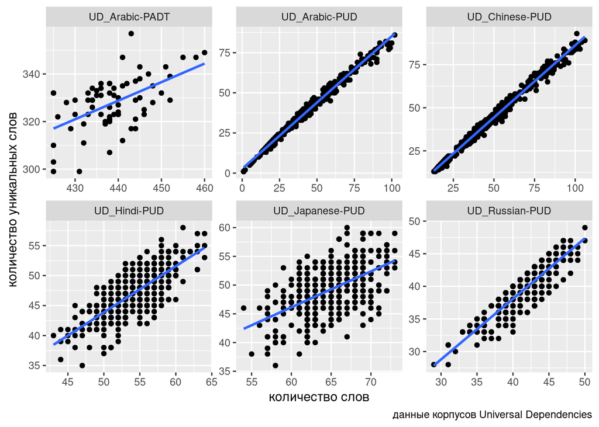

```r
library(tidyverse)
ud <- read_csv("https://raw.githubusercontent.com/agricolamz/2021_da4l/master/data/ud_corpora.csv")
ud %>%
  ggplot(aes(n_words, n_tokens))+
  geom_point()+
  facet_wrap(~corpus, scale = "free")+
  geom_smooth(method = "lm", se = FALSE)+
  labs(x = "количество слов",
       y = "количество уникальных слов",
       caption = "данные корпусов Universal Dependencies")
```

Связь между переменными безусловно линейная, однако в разных корпусах представлена разная перспектива: для каких-то корпусов, видимо, тексты специально нарезались, так что тексты таких корпусов содержат от 30-40 до 50-80 слов, а какие-то оставались не тронутыми. Чтобы показать, что связь есть, нельзя просто “слить” все наблюдения в один котел (см. [парадокс Симпсона](https://en.wikipedia.org/wiki/Simpson%27s_paradox)), так как это нарушит предположение регрессии о независимости наблюдений. Мы не можем включить переменную `corpus` в качестве dummy-переменной: тогда один из корпусов попадет в интерсепт (станет своего рода базовым уровенем), а остальные будут от него отсчитываться. К тому же не очень понятно, как работать с новыми данными из других корпусов: ведь мы хотим предсказывать значения обобщенно, вне зависимости от корпуса.

При моделировании при помощи моделей со случайными эффектами различают:

- *основные эффекты* – это те связи, которые нас интересуют, независимые переменные (количество слов, количество уникальных слов);
- *случайные эффекты* – это те переменные, которые создают группировку в данных (корпус).

В результате моделирования появляется обобщенная модель, которая игнорирует группировку, а потом для каждого значения случайного эффекта генерируется своя регрессия, отсчитывая от обобщенной модели как от базового уровня.

Рассмотрим простейший случай:

```r
library(lme4)
library(lmerTest)
fit0 <- lm(n_tokens~n_words, data = ud)
summary(fit0)
```

```
##
## Call:
## lm(formula = n_tokens ~ n_words, data = ud)
##
## Residuals:
##     Min      1Q  Median      3Q     Max
## -23.352  -2.245   0.423   2.890  25.849
##
## Coefficients:
##             Estimate Std. Error t value Pr(>|t|)
## (Intercept) 6.313122   0.120060   52.58   <2e-16 ***
## n_words     0.733269   0.001255  584.11   <2e-16 ***
## ---
## Signif. codes:  0 '***' 0.001 '**' 0.01 '*' 0.05 '.' 0.1 ' ' 1
##
## Residual standard error: 4.114 on 2044 degrees of freedom
## Multiple R-squared:  0.994,  Adjusted R-squared:  0.994
## F-statistic: 3.412e+05 on 1 and 2044 DF,  p-value: < 2.2e-16
```

```r
fit1 <- lmer(n_tokens~n_words+(1|corpus), data = ud)
summary(fit1)
```

```
## Linear mixed model fit by REML. t-tests use Satterthwaite's method [
## lmerModLmerTest]
## Formula: n_tokens ~ n_words + (1 | corpus)
##    Data: ud
##
## REML criterion at convergence: 10321.5
##
## Scaled residuals:
##     Min      1Q  Median      3Q     Max
## -7.5271 -0.4947  0.0354  0.5282  8.6350
##
## Random effects:
##  Groups   Name        Variance Std.Dev.
##  corpus   (Intercept) 240.608  15.512
##  Residual               8.844   2.974
## Number of obs: 2046, groups:  corpus, 6
##
## Fixed effects:
##               Estimate Std. Error         df t value Pr(>|t|)
## (Intercept) -4.528e+00  6.353e+00  4.959e+00  -0.713    0.508
## n_words      8.279e-01  4.418e-03  1.993e+03 187.415   <2e-16 ***
## ---
## Signif. codes:  0 '***' 0.001 '**' 0.01 '*' 0.05 '.' 0.1 ' ' 1
##
## Correlation of Fixed Effects:
##         (Intr)
## n_words -0.079
```

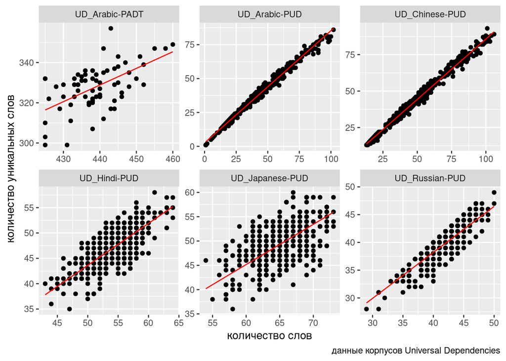

```r
ud %>%
  mutate(predicted = predict(fit1)) %>%
  ggplot(aes(n_words, n_tokens))+
  geom_point()+
  facet_wrap(~corpus, scale = "free")+
  geom_line(aes(y = predicted), color = "red") +
  labs(x = "количество слов",
       y = "количество уникальных слов",
       caption = "данные корпусов Universal Dependencies")
```

Можно посмотреть на предсказания модели (основные эффекты):

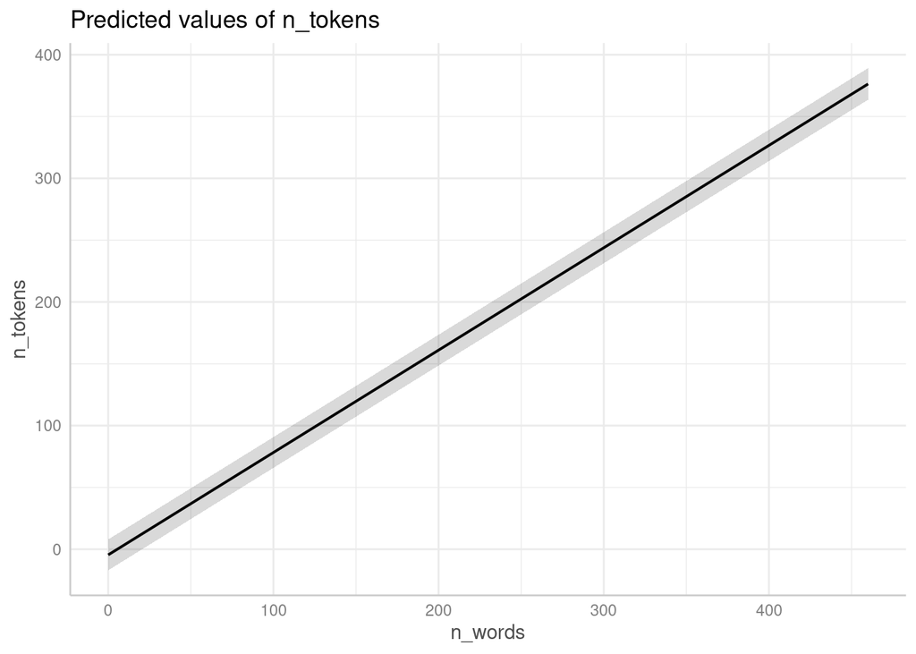

```r
library(ggeffects)
ggeffect(fit1) %>%
  plot()
```

Визуализируйте полученные модели при помощи функции `plot()`. Какие ограничения на применение линейной регрессии нарушается в наших моделях?

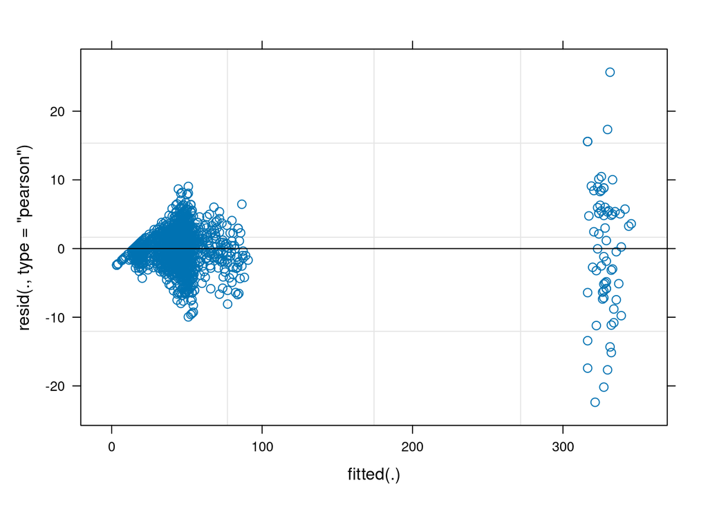

```r
plot(fit1)
```

```r
fit2 <- lmer(n_tokens~n_words+(1+n_words|corpus), data = ud)
```

```
## boundary (singular) fit: see help('isSingular')
```

```r
summary(fit2)
```

```
## Linear mixed model fit by REML. t-tests use Satterthwaite's method [
## lmerModLmerTest]
## Formula: n_tokens ~ n_words + (1 + n_words | corpus)
##    Data: ud
##
## REML criterion at convergence: 10275.2
##
## Scaled residuals:
##     Min      1Q  Median      3Q     Max
## -7.8337 -0.5003  0.0293  0.5172  8.8405
##
## Random effects:
##  Groups   Name        Variance Std.Dev. Corr
##  corpus   (Intercept) 4.465751 2.11323
##           n_words     0.009532 0.09763  -1.00
##  Residual             8.693060 2.94840
## Number of obs: 2046, groups:  corpus, 6
##
## Fixed effects:
##             Estimate Std. Error      df t value Pr(>|t|)
## (Intercept)  3.23103    0.88937 2.21775   3.633   0.0582 .
## n_words      0.80323    0.04005 4.10414  20.056 2.99e-05 ***
## ---
## Signif. codes:  0 '***' 0.001 '**' 0.01 '*' 0.05 '.' 0.1 ' ' 1
##
## Correlation of Fixed Effects:
##         (Intr)
## n_words -0.988
## optimizer (nloptwrap) convergence code: 0 (OK)
## boundary (singular) fit: see help('isSingular')
```

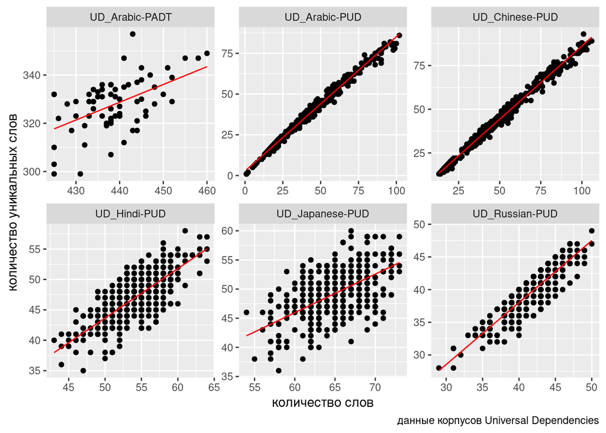

```r
ud %>%
  mutate(predicted = predict(fit2)) %>%
  ggplot(aes(n_words, n_tokens))+
  geom_point()+
  facet_wrap(~corpus, scale = "free")+
  geom_line(aes(y = predicted), color = "red") +
  labs(x = "количество слов",
       y = "количество уникальных слов",
       caption = "данные корпусов Universal Dependencies")
```

Можно посмотреть на предсказания модели (основные эффекты):

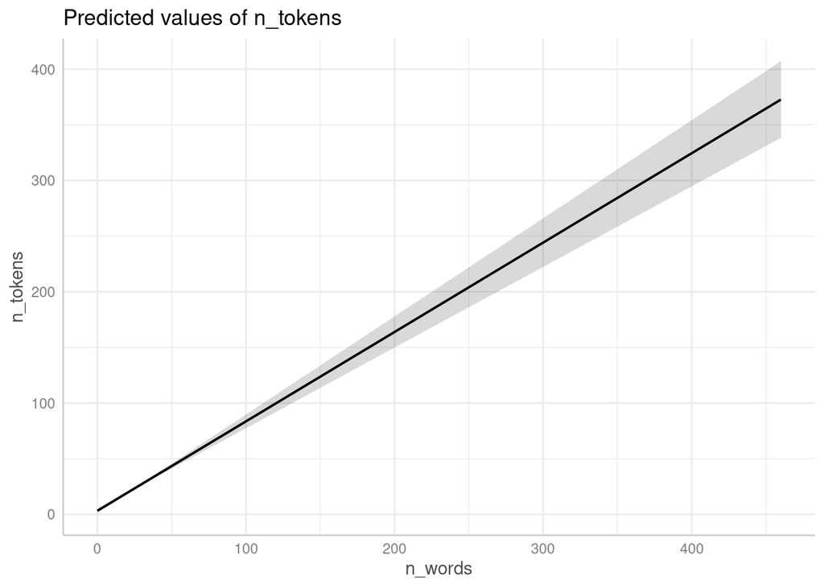

```r
ggeffect(fit2) %>%
  plot()
```

Нарушения все те же:

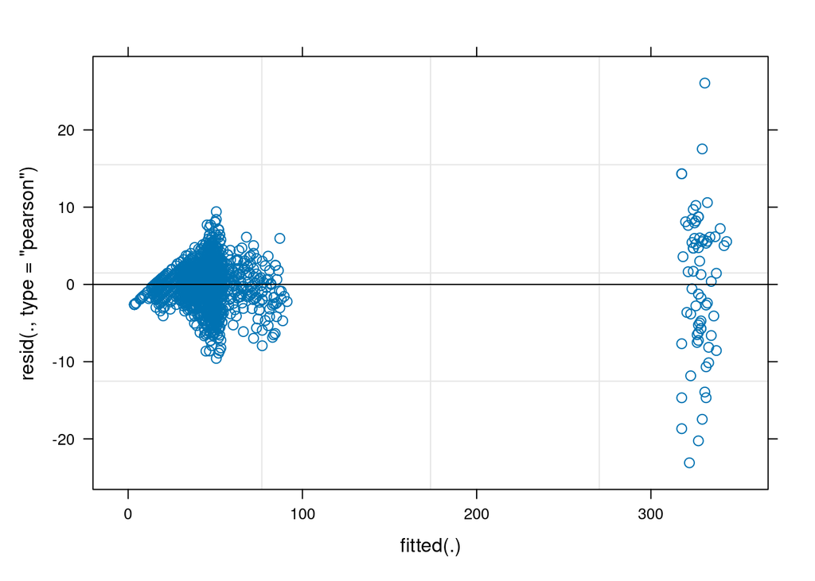

```r
plot(fit2)
```

При желании мы можем также построить модель, в которой в случайном эффекте будет лишь угловой коэффициент, а свободный член будет фиксированным:

```r
fit3 <- lmer(n_tokens~n_words+(0+n_words|corpus), data = ud)
summary(fit3)
```

```
## Linear mixed model fit by REML. t-tests use Satterthwaite's method [
## lmerModLmerTest]
## Formula: n_tokens ~ n_words + (0 + n_words | corpus)
##    Data: ud
##
## REML criterion at convergence: 10280.9
##
## Scaled residuals:
##     Min      1Q  Median      3Q     Max
## -7.8107 -0.4933  0.0315  0.5227  8.8209
##
## Random effects:
##  Groups   Name    Variance Std.Dev.
##  corpus   n_words 0.004023 0.06343
##  Residual         8.717996 2.95263
## Number of obs: 2046, groups:  corpus, 6
##
## Fixed effects:
##              Estimate Std. Error        df t value Pr(>|t|)
## (Intercept) 2.648e+00  2.163e-01 2.044e+03   12.24  < 2e-16 ***
## n_words     8.043e-01  2.615e-02 5.162e+00   30.76 4.77e-07 ***
## ---
## Signif. codes:  0 '***' 0.001 '**' 0.01 '*' 0.05 '.' 0.1 ' ' 1
##
## Correlation of Fixed Effects:
##         (Intr)
## n_words -0.132
```

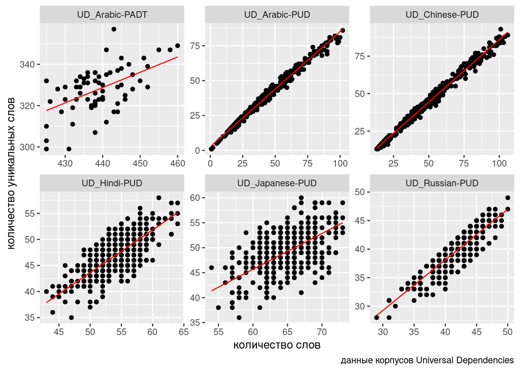

```r
ud %>%
  mutate(predicted = predict(fit3)) %>%
  ggplot(aes(n_words, n_tokens))+
  geom_point()+
  facet_wrap(~corpus, scale = "free")+
  geom_line(aes(y = predicted), color = "red") +
  labs(x = "количество слов",
       y = "количество уникальных слов",
       caption = "данные корпусов Universal Dependencies")
```

Линии получились очень похожими, но разными:

[figure not shown]

Можно посмотреть на предсказания модели (основные эффекты):

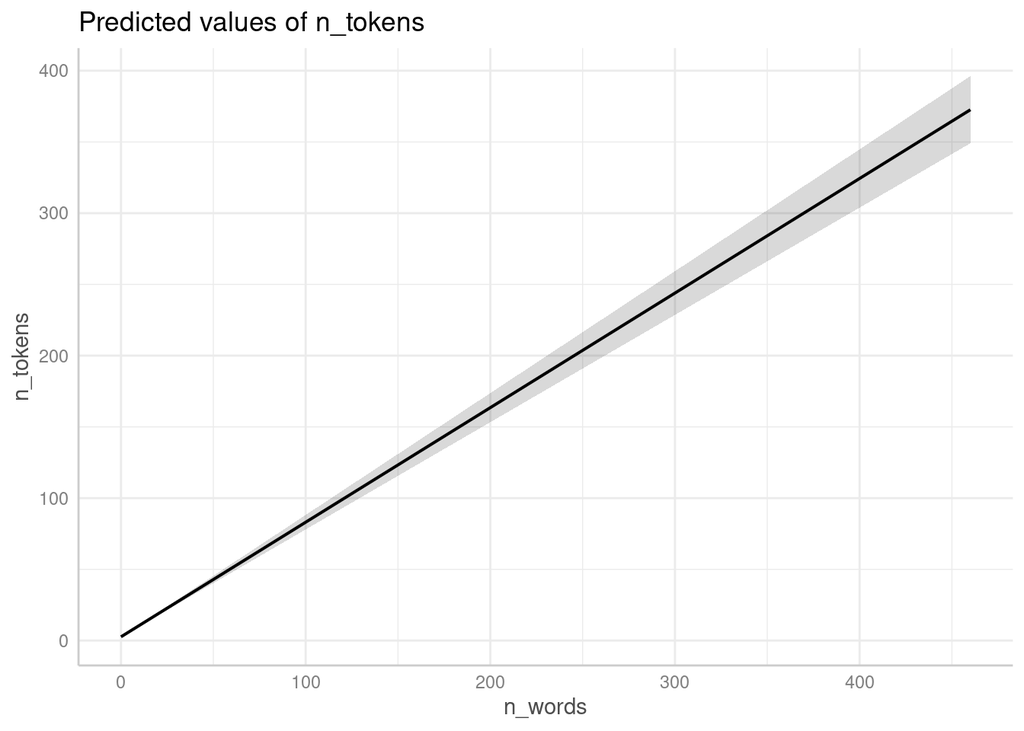

```r
ggeffect(fit3) %>%
  plot()
```

Нарушения все те же:

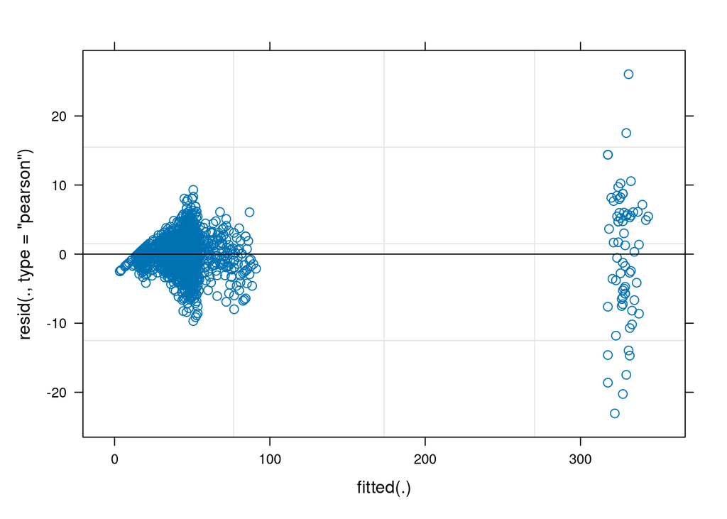

```r
plot(fit3)
```

Сравним полученные модели:

```r
anova(fit3, fit2, fit1)
```

```
## refitting model(s) with ML (instead of REML)
```

```
## Data: ud
## Models:
## fit3: n_tokens ~ n_words + (0 + n_words | corpus)
## fit1: n_tokens ~ n_words + (1 | corpus)
## fit2: n_tokens ~ n_words + (1 + n_words | corpus)
##      npar   AIC   BIC  logLik -2*log(L)  Chisq Df Pr(>Chisq)
## fit3    4 10282 10305 -5137.1     10274
## fit1    4 10326 10348 -5159.0     10318  0.000  0
## fit2    6 10280 10314 -5134.2     10268 49.594  2  1.701e-11 ***
## ---
## Signif. codes:  0 '***' 0.001 '**' 0.01 '*' 0.05 '.' 0.1 ' ' 1
```

Постройте модель со случайными угловым коэффициентом и свободным членом, устранив проблему, которую вы заметили в прошлом задании.

Пользуясь знаниями из предыдущих заданий, смоделируйте связь количества слов и количества существительных. С какими проблемами вы столкнулись?

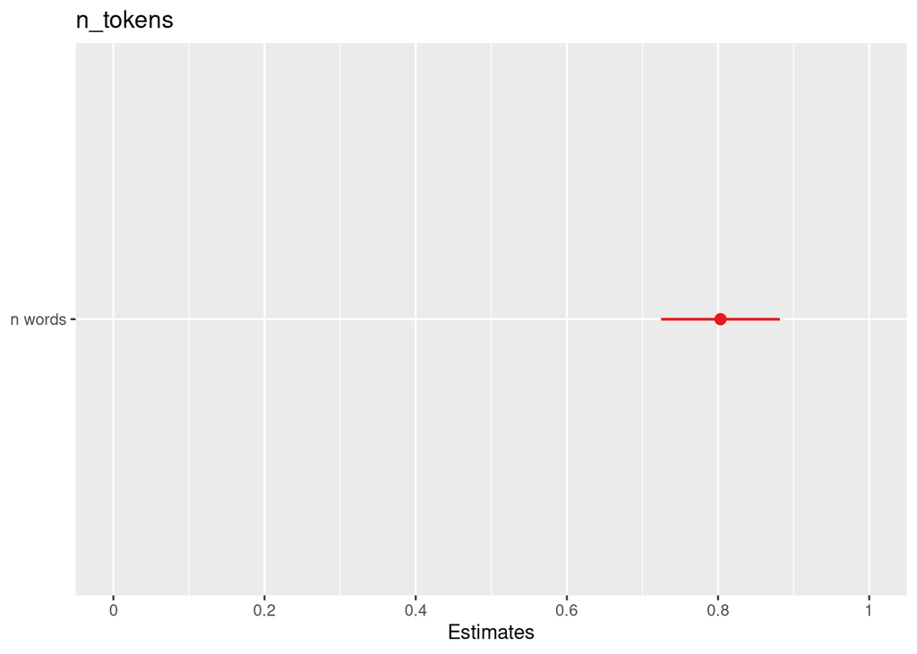

```r
library(sjPlot)
plot_model(fit2)
```

```r
data <- read.csv("https://raw.githubusercontent.com/olesar/2023dav4compling/main/data/icelandic.csv")
data
```

[output not shown]

[output cut: 3213 more lines]

```r
avg_vowel_dur <- data %>%
  group_by(place) %>%
  summarise(mean_vowel_dur = mean(vowel.dur, na.rm = TRUE))
avg_vowel_dur
```

```
## # A tibble: 3 × 2
##   place   mean_vowel_dur
##   <chr>            <dbl>
## 1 coronal           91.0
## 2 labial            77.3
## 3 velar             90.2
```

```r
avg_vowel_dur <- data %>%
  group_by(speaker) %>%
  summarise(mean_vowel_dur = mean(vowel.dur, na.rm = TRUE))
avg_vowel_dur
```

```
## # A tibble: 5 × 2
##   speaker mean_vowel_dur
##   <chr>            <dbl>
## 1 brs02             83.6
## 2 bte03             99.2
## 3 jj04              91.5
## 4 shg05             70.1
## 5 tt01              89.4
```

```r
avg_vowel_dur <- data %>%
  group_by(place, speaker) %>%
  summarise(mean_vowel_dur = mean(vowel.dur, na.rm = TRUE))
avg_vowel_dur
```

```
## # A tibble: 15 × 3
## # Groups:   place [3]
##    place   speaker mean_vowel_dur
##    <chr>   <chr>            <dbl>
##  1 coronal brs02             86.7
##  2 coronal bte03            105.
##  3 coronal jj04              97.7
##  4 coronal shg05             73.8
##  5 coronal tt01              92.0
##  6 labial  brs02             75.2
##  7 labial  bte03             87.8
##  8 labial  jj04              79.6
##  9 labial  shg05             59.9
## 10 labial  tt01              84.7
## 11 velar   brs02             90.3
## 12 velar   bte03             98.1
## 13 velar   jj04              93.6
## 14 velar   shg05             80.3
## 15 velar   tt01              88.8
```

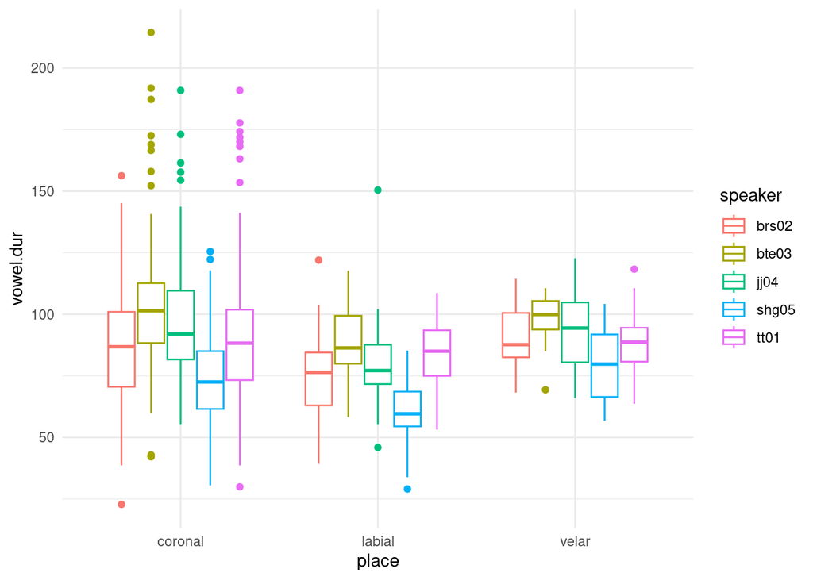

```r
ggplot(data, aes(x = place, y = vowel.dur, color = speaker)) +
  geom_boxplot() +
  labs(x = "place",
       y = "vowel.dur") +
  theme_minimal()
```

```r
avg_vowel_dur_word <- data %>%
  group_by(word) %>%
  summarise(mean_vowel_dur = mean(vowel.dur, na.rm = TRUE))
avg_vowel_dur_word
```

```
## # A tibble: 58 × 2
##    word  mean_vowel_dur
##    <chr>          <dbl>
##  1 detta           72.8
##  2 duld           102.
##  3 dult            80.7
##  4 dögg           101.
##  5 dökk            80.6
##  6 feits          157.
##  7 feitt           86.6
##  8 fæddi           97.4
##  9 fætt            88.7
## 10 fínn            88.6
## # ℹ 48 more rows
```

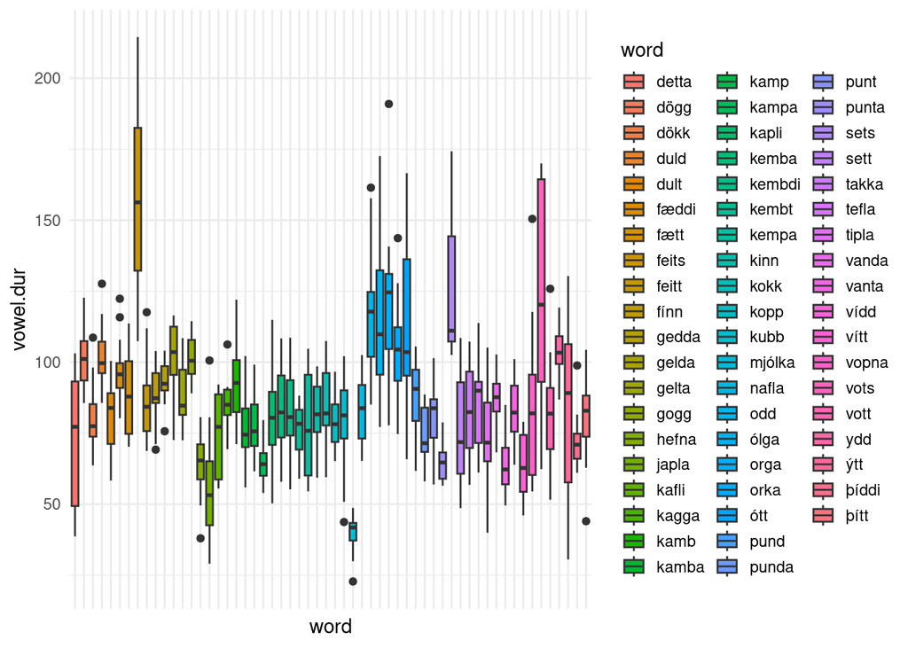

```r
ggplot(data, aes(x = word, y = vowel.dur, fill=word)) +
  geom_boxplot() +
  labs(x = "word",
       y = "vowel.dur") +
  theme_minimal() +
  theme(axis.text.x = element_blank(), legend.key.size = unit(0.5, "cm"))
```

```r
model <- lmer(vowel.dur ~ place + (1 | speaker), data = data)
summary(model)
```

```
## Linear mixed model fit by REML. t-tests use Satterthwaite's method [
## lmerModLmerTest]
## Formula: vowel.dur ~ place + (1 | speaker)
##    Data: data
##
## REML criterion at convergence: 7292.9
##
## Scaled residuals:
##     Min      1Q  Median      3Q     Max
## -2.9226 -0.5708 -0.0926  0.4450  5.0208
##
## Random effects:
##  Groups   Name        Variance Std.Dev.
##  speaker  (Intercept) 111.6    10.57
##  Residual             495.8    22.27
## Number of obs: 806, groups:  speaker, 5
##
## Fixed effects:
##             Estimate Std. Error       df t value Pr(>|t|)
## (Intercept)  90.9320     4.8361   4.1545  18.803 3.54e-05 ***
## placelabial -13.3303     1.7503 799.0407  -7.616 7.40e-14 ***
## placevelar   -0.7663     2.5516 799.0054  -0.300    0.764
## ---
## Signif. codes:  0 '***' 0.001 '**' 0.01 '*' 0.05 '.' 0.1 ' ' 1
##
## Correlation of Fixed Effects:
##             (Intr) plclbl
## placelabial -0.126
## placevelar  -0.086  0.238
```

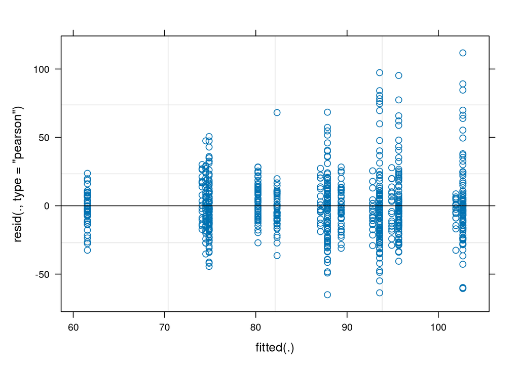

```r
plot(model)
```

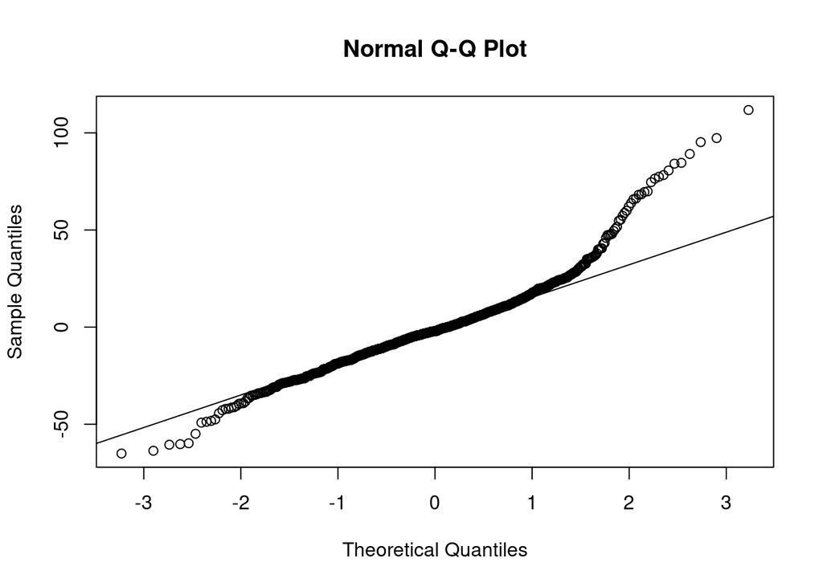

```r
qqnorm(resid(model))
qqline(resid(model))
```